# Optimal Treatment Analysis

## Outcome Variable

**Outcome Variable:** whz

## Predictor Variables

**Intervention Variable:** hfoodsec

**Adjustment Set:**

- arm
- sex
- W_mage
- meducyrs
- feducyrs
- hhwealth_quart
- vagbrth
- W_nrooms
- W_nchldlt5
- brthmon
- W_parity
- impfloor
- impsan
- safeh20
- delta_W_mage
- delta_meducyrs
- delta_feducyrs
- delta_hhwealth_quart
- delta_vagbrth
- delta_W_nrooms
- delta_W_nchldlt5
- delta_brthmon
- delta_W_parity
- delta_impfloor
- delta_impsan
- delta_safeh20

## Stratifying Variables

The analysis was stratified on these variable(s):

- agecat
- studyid
- country

## Data Summary

| agecat | studyid | country | hfoodsec | n_cell | n |
| --- | --- | --- | --- | --- | --- |
| Birth | ki0047075b-MAL-ED | BANGLADESH | Food Secure | 138 | 162 |
| Birth | ki0047075b-MAL-ED | BANGLADESH | Mildly Food Insecure | 3 | 162 |
| Birth | ki0047075b-MAL-ED | BANGLADESH | Food Insecure | 21 | 162 |
| Birth | ki0047075b-MAL-ED | BRAZIL | Food Secure | 0 | 26 |
| Birth | ki0047075b-MAL-ED | BRAZIL | Mildly Food Insecure | 4 | 26 |
| Birth | ki0047075b-MAL-ED | BRAZIL | Food Insecure | 22 | 26 |
| Birth | ki0047075b-MAL-ED | INDIA | Food Secure | 32 | 35 |
| Birth | ki0047075b-MAL-ED | INDIA | Mildly Food Insecure | 1 | 35 |
| Birth | ki0047075b-MAL-ED | INDIA | Food Insecure | 2 | 35 |
| Birth | ki0047075b-MAL-ED | NEPAL | Food Secure | 10 | 14 |
| Birth | ki0047075b-MAL-ED | NEPAL | Mildly Food Insecure | 1 | 14 |
| Birth | ki0047075b-MAL-ED | NEPAL | Food Insecure | 3 | 14 |
| Birth | ki0047075b-MAL-ED | PERU | Food Secure | 23 | 89 |
| Birth | ki0047075b-MAL-ED | PERU | Mildly Food Insecure | 22 | 89 |
| Birth | ki0047075b-MAL-ED | PERU | Food Insecure | 44 | 89 |
| Birth | ki0047075b-MAL-ED | SOUTH AFRICA | Food Secure | 45 | 87 |
| Birth | ki0047075b-MAL-ED | SOUTH AFRICA | Mildly Food Insecure | 9 | 87 |
| Birth | ki0047075b-MAL-ED | SOUTH AFRICA | Food Insecure | 33 | 87 |
| Birth | ki1017093-NIH-Birth | BANGLADESH | Food Secure | 86 | 575 |
| Birth | ki1017093-NIH-Birth | BANGLADESH | Mildly Food Insecure | 453 | 575 |
| Birth | ki1017093-NIH-Birth | BANGLADESH | Food Insecure | 36 | 575 |
| Birth | ki1017093c-NIH-Crypto | BANGLADESH | Food Secure | 429 | 707 |
| Birth | ki1017093c-NIH-Crypto | BANGLADESH | Mildly Food Insecure | 199 | 707 |
| Birth | ki1017093c-NIH-Crypto | BANGLADESH | Food Insecure | 79 | 707 |
| Birth | ki1113344-GMS-Nepal | NEPAL | Food Secure | 442 | 620 |
| Birth | ki1113344-GMS-Nepal | NEPAL | Mildly Food Insecure | 100 | 620 |
| Birth | ki1113344-GMS-Nepal | NEPAL | Food Insecure | 78 | 620 |
| Birth | kiGH5241-JiVitA-3 | BANGLADESH | Food Secure | 7326 | 14320 |
| Birth | kiGH5241-JiVitA-3 | BANGLADESH | Mildly Food Insecure | 4693 | 14320 |
| Birth | kiGH5241-JiVitA-3 | BANGLADESH | Food Insecure | 2301 | 14320 |

[output cut: 69 more lines]

The following strata were considered:

- agecat: 24 months, studyid: ki0047075b-MAL-ED, country: BANGLADESH
- agecat: 24 months, studyid: ki0047075b-MAL-ED, country: BRAZIL
- agecat: 24 months, studyid: ki0047075b-MAL-ED, country: INDIA
- agecat: 24 months, studyid: ki0047075b-MAL-ED, country: NEPAL
- agecat: 24 months, studyid: ki0047075b-MAL-ED, country: PERU
- agecat: 24 months, studyid: ki0047075b-MAL-ED, country: SOUTH AFRICA
- agecat: 24 months, studyid: ki1017093-NIH-Birth, country: BANGLADESH
- agecat: 24 months, studyid: ki1017093c-NIH-Crypto, country: BANGLADESH
- agecat: 24 months, studyid: ki1113344-GMS-Nepal, country: NEPAL
- agecat: 24 months, studyid: kiGH5241-JiVitA-3, country: BANGLADESH
- agecat: 24 months, studyid: kiGH5241-JiVitA-4, country: BANGLADESH
- agecat: 6 months, studyid: ki0047075b-MAL-ED, country: BANGLADESH
- agecat: 6 months, studyid: ki0047075b-MAL-ED, country: BRAZIL
- agecat: 6 months, studyid: ki0047075b-MAL-ED, country: INDIA
- agecat: 6 months, studyid: ki0047075b-MAL-ED, country: NEPAL
- agecat: 6 months, studyid: ki0047075b-MAL-ED, country: PERU
- agecat: 6 months, studyid: ki0047075b-MAL-ED, country: SOUTH AFRICA
- agecat: 6 months, studyid: ki1017093-NIH-Birth, country: BANGLADESH
- agecat: 6 months, studyid: ki1017093c-NIH-Crypto, country: BANGLADESH
- agecat: 6 months, studyid: ki1113344-GMS-Nepal, country: NEPAL
- agecat: 6 months, studyid: kiGH5241-JiVitA-3, country: BANGLADESH
- agecat: 6 months, studyid: kiGH5241-JiVitA-4, country: BANGLADESH
- agecat: Birth, studyid: ki0047075b-MAL-ED, country: BANGLADESH
- agecat: Birth, studyid: ki0047075b-MAL-ED, country: BRAZIL
- agecat: Birth, studyid: ki0047075b-MAL-ED, country: INDIA
- agecat: Birth, studyid: ki0047075b-MAL-ED, country: NEPAL
- agecat: Birth, studyid: ki0047075b-MAL-ED, country: PERU
- agecat: Birth, studyid: ki0047075b-MAL-ED, country: SOUTH AFRICA
- agecat: Birth, studyid: ki1017093-NIH-Birth, country: BANGLADESH
- agecat: Birth, studyid: ki1017093c-NIH-Crypto, country: BANGLADESH
- agecat: Birth, studyid: ki1113344-GMS-Nepal, country: NEPAL
- agecat: Birth, studyid: kiGH5241-JiVitA-3, country: BANGLADESH
- agecat: Birth, studyid: kiGH5241-JiVitA-4, country: BANGLADESH

### Dropped Strata

Some strata were dropped due to rare outcomes:

- agecat: Birth, studyid: ki0047075b-MAL-ED, country: BANGLADESH
- agecat: Birth, studyid: ki0047075b-MAL-ED, country: BRAZIL
- agecat: Birth, studyid: ki0047075b-MAL-ED, country: INDIA
- agecat: Birth, studyid: ki0047075b-MAL-ED, country: NEPAL
- agecat: 6 months, studyid: ki0047075b-MAL-ED, country: BANGLADESH
- agecat: 6 months, studyid: ki0047075b-MAL-ED, country: BRAZIL
- agecat: 24 months, studyid: ki0047075b-MAL-ED, country: BANGLADESH
- agecat: 24 months, studyid: ki0047075b-MAL-ED, country: BRAZIL

## Methods Detail

We’re interested in the causal parameters $E[Y_a]$ for all values of $a \in \mathcal{A}$. These parameters represent the mean outcome if, possibly contrary to fact, we intervened to set all units to have $A=a$. Under the randomization and positivity assumptions, these are identified by the statistical parameters $\psi_a=E_W[E_{Y|A,W}(Y|A=a,W)]$. In addition, we’re interested in the mean of $Y$, $E[Y]$ under no intervention (the observed mean). We will estimate these parameters by using SuperLearner to fit the relevant likelihood factors – $E_{Y|A,W}(Y|A=a,W)$ and $p(A=a|W)$, and then updating our likelihood fit using a joint TMLE.

For unadjusted analyses ($W=\{\}$), initial likelihoods were estimated using Lrnr_glm to estimate the simple $E(Y|A)$ and Lrnr_mean to estimate $p(A)$. For adjusted analyses, a small library containing Lrnr_glmnet, Lrnr_xgboost, and Lrnr_mean was used.

Having estimated these parameters, we will then use the delta method to estimate relative risks and attributable risks relative to a prespecified baseline level of $A$.

# Results Detail

## Results Plots

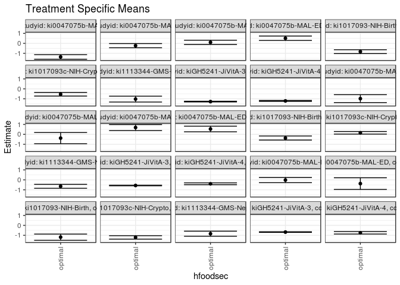

## Results Table

### Parameter: TSM

| agecat | studyid | country | intervention_level | baseline_level | estimate | ci_lower | ci_upper |
| --- | --- | --- | --- | --- | --- | --- | --- |
| Birth | ki0047075b-MAL-ED | PERU | optimal | observed | -0.0182738 | -0.2773914 | 0.2408438 |
| Birth | ki0047075b-MAL-ED | SOUTH AFRICA | optimal | observed | -0.3761955 | -0.9615835 | 0.2091926 |
| Birth | ki1017093-NIH-Birth | BANGLADESH | optimal | observed | -1.1887678 | -1.4991393 | -0.8783962 |
| Birth | ki1017093c-NIH-Crypto | BANGLADESH | optimal | observed | -1.2109503 | -1.3824939 | -1.0394068 |
| Birth | ki1113344-GMS-Nepal | NEPAL | optimal | observed | -0.8411761 | -1.0969585 | -0.5853937 |
| Birth | kiGH5241-JiVitA-3 | BANGLADESH | optimal | observed | -0.6780886 | -0.7072024 | -0.6489747 |
| Birth | kiGH5241-JiVitA-4 | BANGLADESH | optimal | observed | -0.7482194 | -0.8737220 | -0.6227168 |
| 6 months | ki0047075b-MAL-ED | INDIA | optimal | observed | -0.9826494 | -1.3802447 | -0.5850540 |
| 6 months | ki0047075b-MAL-ED | NEPAL | optimal | observed | -0.3786849 | -0.9422200 | 0.1848502 |
| 6 months | ki0047075b-MAL-ED | PERU | optimal | observed | 0.6858329 | 0.3835554 | 0.9881105 |
| 6 months | ki0047075b-MAL-ED | SOUTH AFRICA | optimal | observed | 0.5401493 | 0.2573285 | 0.8229701 |
| 6 months | ki1017093-NIH-Birth | BANGLADESH | optimal | observed | -0.3694041 | -0.5728470 | -0.1659611 |
| 6 months | ki1017093c-NIH-Crypto | BANGLADESH | optimal | observed | 0.1541268 | 0.0252487 | 0.2830049 |
| 6 months | ki1113344-GMS-Nepal | NEPAL | optimal | observed | -0.6489728 | -0.8469894 | -0.4509561 |
| 6 months | kiGH5241-JiVitA-3 | BANGLADESH | optimal | observed | -0.5666815 | -0.5951988 | -0.5381642 |
| 6 months | kiGH5241-JiVitA-4 | BANGLADESH | optimal | observed | -0.3966593 | -0.4907669 | -0.3025518 |
| 24 months | ki0047075b-MAL-ED | INDIA | optimal | observed | -1.3663806 | -1.5979954 | -1.1347659 |
| 24 months | ki0047075b-MAL-ED | NEPAL | optimal | observed | -0.2344421 | -0.4430015 | -0.0258827 |
| 24 months | ki0047075b-MAL-ED | PERU | optimal | observed | 0.1031207 | -0.1106870 | 0.3169285 |
| 24 months | ki0047075b-MAL-ED | SOUTH AFRICA | optimal | observed | 0.5148579 | 0.2929750 | 0.7367407 |
| 24 months | ki1017093-NIH-Birth | BANGLADESH | optimal | observed | -0.8341913 | -1.0271454 | -0.6412373 |
| 24 months | ki1017093c-NIH-Crypto | BANGLADESH | optimal | observed | -0.5403697 | -0.7214764 | -0.3592630 |
| 24 months | ki1113344-GMS-Nepal | NEPAL | optimal | observed | -1.0296767 | -1.3246740 | -0.7346794 |
| 24 months | kiGH5241-JiVitA-3 | BANGLADESH | optimal | observed | -1.2826256 | -1.3174795 | -1.2477717 |
| 24 months | kiGH5241-JiVitA-4 | BANGLADESH | optimal | observed | -1.2124147 | -1.2569358 | -1.1678936 |

### Parameter: E(Y)

| agecat | studyid | country | intervention_level | baseline_level | estimate | ci_lower | ci_upper |
| --- | --- | --- | --- | --- | --- | --- | --- |
| Birth | ki0047075b-MAL-ED | PERU | observed | observed | -0.0483146 | -0.2475806 | 0.1509514 |
| Birth | ki0047075b-MAL-ED | SOUTH AFRICA | observed | observed | -0.1502299 | -0.4075620 | 0.1071022 |
| Birth | ki1017093-NIH-Birth | BANGLADESH | observed | observed | -1.3499217 | -1.4444634 | -1.2553801 |
| Birth | ki1017093c-NIH-Crypto | BANGLADESH | observed | observed | -1.2441513 | -1.3281130 | -1.1601897 |
| Birth | ki1113344-GMS-Nepal | NEPAL | observed | observed | -1.1165161 | -1.2055683 | -1.0274639 |
| Birth | kiGH5241-JiVitA-3 | BANGLADESH | observed | observed | -0.7208547 | -0.7418118 | -0.6998977 |
| Birth | kiGH5241-JiVitA-4 | BANGLADESH | observed | observed | -0.6898154 | -0.7422632 | -0.6373675 |
| 6 months | ki0047075b-MAL-ED | INDIA | observed | observed | -0.7227752 | -0.8585532 | -0.5869972 |
| 6 months | ki0047075b-MAL-ED | NEPAL | observed | observed | 0.1289063 | -0.0638567 | 0.3216692 |
| 6 months | ki0047075b-MAL-ED | PERU | observed | observed | 0.9840541 | 0.7695460 | 1.1985621 |
| 6 months | ki0047075b-MAL-ED | SOUTH AFRICA | observed | observed | 0.5429678 | 0.3813968 | 0.7045389 |
| 6 months | ki1017093-NIH-Birth | BANGLADESH | observed | observed | -0.4474038 | -0.5378167 | -0.3569909 |
| 6 months | ki1017093c-NIH-Crypto | BANGLADESH | observed | observed | 0.0297622 | -0.0491685 | 0.1086930 |
| 6 months | ki1113344-GMS-Nepal | NEPAL | observed | observed | -0.6018803 | -0.6892284 | -0.5145323 |
| 6 months | kiGH5241-JiVitA-3 | BANGLADESH | observed | observed | -0.5927331 | -0.6123184 | -0.5731479 |
| 6 months | kiGH5241-JiVitA-4 | BANGLADESH | observed | observed | -0.3895527 | -0.4270314 | -0.3520739 |
| 24 months | ki0047075b-MAL-ED | INDIA | observed | observed | -0.9595519 | -1.0781202 | -0.8409836 |
| 24 months | ki0047075b-MAL-ED | NEPAL | observed | observed | -0.2757812 | -0.4379560 | -0.1136065 |
| 24 months | ki0047075b-MAL-ED | PERU | observed | observed | 0.0990187 | -0.0788709 | 0.2769082 |
| 24 months | ki0047075b-MAL-ED | SOUTH AFRICA | observed | observed | 0.4141009 | 0.2892188 | 0.5389829 |
| 24 months | ki1017093-NIH-Birth | BANGLADESH | observed | observed | -0.9115790 | -1.0095022 | -0.8136559 |
| 24 months | ki1017093c-NIH-Crypto | BANGLADESH | observed | observed | -0.6103502 | -0.7050157 | -0.5156847 |
| 24 months | ki1113344-GMS-Nepal | NEPAL | observed | observed | -1.1304997 | -1.2205265 | -1.0404728 |
| 24 months | kiGH5241-JiVitA-3 | BANGLADESH | observed | observed | -1.3003702 | -1.3240616 | -1.2766787 |
| 24 months | kiGH5241-JiVitA-4 | BANGLADESH | observed | observed | -1.2243590 | -1.2566569 | -1.1920612 |

### Parameter: PAR

| agecat | studyid | country | intervention_level | baseline_level | estimate | ci_lower | ci_upper |
| --- | --- | --- | --- | --- | --- | --- | --- |
| Birth | ki0047075b-MAL-ED | PERU | optimal | observed | -0.0300408 | -0.2728332 | 0.2127515 |
| Birth | ki0047075b-MAL-ED | SOUTH AFRICA | optimal | observed | 0.2259656 | -0.2790932 | 0.7310243 |
| Birth | ki1017093-NIH-Birth | BANGLADESH | optimal | observed | -0.1611540 | -0.4558587 | 0.1335508 |
| Birth | ki1017093c-NIH-Crypto | BANGLADESH | optimal | observed | -0.0332010 | -0.1795771 | 0.1131751 |
| Birth | ki1113344-GMS-Nepal | NEPAL | optimal | observed | -0.2753400 | -0.5101737 | -0.0405064 |
| Birth | kiGH5241-JiVitA-3 | BANGLADESH | optimal | observed | -0.0427662 | -0.0621803 | -0.0233521 |
| Birth | kiGH5241-JiVitA-4 | BANGLADESH | optimal | observed | 0.0584040 | -0.0528082 | 0.1696163 |
| 6 months | ki0047075b-MAL-ED | INDIA | optimal | observed | 0.2598742 | -0.1152073 | 0.6349557 |
| 6 months | ki0047075b-MAL-ED | NEPAL | optimal | observed | 0.5075911 | -0.0207823 | 1.0359646 |
| 6 months | ki0047075b-MAL-ED | PERU | optimal | observed | 0.2982211 | 0.0575910 | 0.5388512 |
| 6 months | ki0047075b-MAL-ED | SOUTH AFRICA | optimal | observed | 0.0028185 | -0.2276797 | 0.2333168 |
| 6 months | ki1017093-NIH-Birth | BANGLADESH | optimal | observed | -0.0779997 | -0.2719739 | 0.1159744 |
| 6 months | ki1017093c-NIH-Crypto | BANGLADESH | optimal | observed | -0.1243645 | -0.2241203 | -0.0246088 |
| 6 months | ki1113344-GMS-Nepal | NEPAL | optimal | observed | 0.0470924 | -0.1389984 | 0.2331832 |
| 6 months | kiGH5241-JiVitA-3 | BANGLADESH | optimal | observed | -0.0260517 | -0.0461255 | -0.0059778 |
| 6 months | kiGH5241-JiVitA-4 | BANGLADESH | optimal | observed | 0.0071067 | -0.0745617 | 0.0887751 |
| 24 months | ki0047075b-MAL-ED | INDIA | optimal | observed | 0.4068287 | 0.1803905 | 0.6332670 |
| 24 months | ki0047075b-MAL-ED | NEPAL | optimal | observed | -0.0413392 | -0.1499511 | 0.0672727 |
| 24 months | ki0047075b-MAL-ED | PERU | optimal | observed | -0.0041021 | -0.2398884 | 0.2316843 |
| 24 months | ki0047075b-MAL-ED | SOUTH AFRICA | optimal | observed | -0.1007570 | -0.2778630 | 0.0763490 |
| 24 months | ki1017093-NIH-Birth | BANGLADESH | optimal | observed | -0.0773877 | -0.2567029 | 0.1019274 |
| 24 months | ki1017093c-NIH-Crypto | BANGLADESH | optimal | observed | -0.0699805 | -0.2273645 | 0.0874035 |
| 24 months | ki1113344-GMS-Nepal | NEPAL | optimal | observed | -0.1008229 | -0.3755622 | 0.1739163 |
| 24 months | kiGH5241-JiVitA-3 | BANGLADESH | optimal | observed | -0.0177446 | -0.0433820 | 0.0078928 |
| 24 months | kiGH5241-JiVitA-4 | BANGLADESH | optimal | observed | -0.0119443 | -0.0432386 | 0.0193500 |